# Chapter 2

## Lists and Tuples

This chapter introduces a new concept:data structure -- a collection of data elements structured in some way the most basic data structure is the sequence(从0开始，第二个数是1）

### Sequence Overview

list can be changed but tuple cannont

```python
edward=['Edward Gumby',42]
john=['John Smith',50]
database=[edward,john]
database
```

```
[['Edward Gumby', 42], ['John Smith', 50]]
```

```python
lin=['Florine Lin',20]
chen=['Yusra Chen',21]
yan=['Kenya Yan',21]
database=[lin,chen,yan]
database
```

```
[['Florine Lin', 20], ['Yusra Chen', 21], ['Kenya Yan', 21]]
```

```python
lin=['Florine Lin',20]
chen=['Yusra Chen',21]
yan=['Kenya Yan',21]
database=[lin,chen,yan]
database[1]
```

```
['Yusra Chen', 21]
```

### Common Sequence Operations

include indexing,slicing,adding,multiplying,and checking for membership,iteration

#### indexing

```python
greeting='Hello'
greeting[0]
```

```
'H'
```

```python
greeting='Hello'
greeting[-1]
```

```
'o'
```

-1就是最后一个元素

```python
'Hello'[1]
```

```
'e'
```

```python
fourth=input('Year:')[3]
```

```python
fourth
```

```
'5'
```

```python
third=input('Day:')[2]
```

```python
third
```

```
'0'
```

```python
# Print out a date,given year, month, and day as numbers
months=[
    'January'
    'February'
    'March'
    'April'
    'May'
    'June'
    'July'
    'August'
    'September'
    'October'
    'November'
    'December'
]
```

```python
# Print out a date,given year, month, and day as numbers
months=[
    'January',
    'February',
    'March',
    'April',
    'May',
    'June',
    'July',
    'August',
    'September',
    'October',
    'November',
    'December',
]
# A list of with one ending for each number from 1 to 31
endings=['st','nd','rd']+17*['th']\
       +['st','nd','rd']+7*['th']\
       +['st']
year=input('Year:')
month=input('Month(1-12):')
day=input('Day(1-31):')
month_number=int(month)
day_number=int(day)
# Remember to subtract 1 from month and day to get a correct index
month_name=months[month_number-1]
ordinal=day+endings[day_number-1]
print(month_name+' '+ordinal+','+year)
```

```
October 1st,2006
```

#### Slicing

```python
tag = '<a href="http://www.python.org">Python web site</a>'
tag[9:30]
```

```
'http://www.python.org'
```

```python
tag[32:-4]
```

```
'Python web site'
```

```python
numbers = [1, 2, 3, 4, 5, 6, 7, 8, 9, 10]
numbers[3:6]
```

```
[4, 5, 6]
```

```python
numbers[0:1]
```

```
[1]
```

简而言之，你提供两个索引作为切片的界限，其中第一个是包含在内的，第二个是排除在外的。

##### A Nifty Shortcut

```python
numbers[7:10]
```

```
[8, 9, 10]
```

```python
numbers[-3:-1]
```

```
[8, 9]
```

```python
numbers[-3:0]
```

```
[]
```

这并非完全是期望的结果。实际上，只要切片中最左侧的索引在序列中的位置晚于第二个索引（在这种情况下，倒数第三个索引晚于第一个索引），结果就总是一个空序列。幸运的是，你可以使用一个捷径：如果切片要延续到序列的末尾，你完全可以省略最后一个索引。

```python
numbers[-3:]
```

```
[8, 9, 10]
```

```python
numbers[:3]
```

```
[1, 2, 3]
```

```python
numbers[:]
```

```
[1, 2, 3, 4, 5, 6, 7, 8, 9, 10]
```

##### Longer Steps

```python
numbers[0:10:1]
```

```
[1, 2, 3, 4, 5, 6, 7, 8, 9, 10]
```

```python
numbers[0:10:2]
```

```
[1, 3, 5, 7, 9]
```

```python
numbers[1:10:2]
```

```
[2, 4, 6, 8, 10]
```

```python
numbers[3:6:3]
```

```
[4]
```

```python
numbers[::4]
```

```
[1, 5, 9]
```

省略起始位置时默认从第一个元素开始计算

```python
numbers[8:3:-1]
```

```
[9, 8, 7, 6, 5]
```

```python
numbers[10:0:-2]
```

```
[10, 8, 6, 4, 2]
```

```python
numbers[10:0:-2]
```

```
[10, 8, 6, 4, 2]
```

```python
numbers[::-2]
```

```
[10, 8, 6, 4, 2]
```

```python
numbers[5::-2]
```

```
[6, 4, 2]
```

```python
numbers[:5:-2]
```

```
[10, 8]
```

#### Adding Sequences

```python
[1,2,3]+[4,5,6]
```

```
[1, 2, 3, 4, 5, 6]
```

```python
[2,4,6]+[1,3,5]
```

```
[2, 4, 6, 1, 3, 5]
```

```python
'Hello'+'World!'
```

```
'HelloWorld!'
```

```python
[1,2,3]+'world'
```

```
---------------------------------------------------------------------------
TypeError                                 Traceback (most recent call last)
Cell In[36], line 1
----> 1 [1,2,3]+'world'

TypeError: can only concatenate list (not "str") to list
```

you can't concatenate a list and a string

#### Multiplication

```python
'python'*5
```

```
'pythonpythonpythonpythonpython'
```

```python
[42]*10
```

```
[42, 42, 42, 42, 42, 42, 42, 42, 42, 42]
```

##### None, Empty Lists, and Initialization

空列表只需用两个方括号（[]）表示 —— 里面什么都没有。如果你想要一个能容纳 10 个元素但里面没有任何有效内容的列表，你可以像之前那样使用 [42]*10，或者更实际一点，使用 [0]*10。这样你就得到了一个包含 10 个零的列表。然而，有时候你会需要一个在某种意义上表示 “无” 的值，就像 “我们还没在这里放任何东西”。这时候你就可以使用 None。None 是一个 Python 值，它的确切含义就是 “这里什么都没有”。所以，如果你想初始化一个长度为 10 的列表，可以这样做：

```python
sequence=[None]*10
sequence=[None,None,None,None,None,None,None,None,None,None]
```

```python
# Prints a sentence in a centered "box" of correct width
sentence=input("Sentence:")
screen_width=80
text_width=len(sentence)
box_width=text_width+6
left_margin=(screen_width-box_width)//2
print()
print(' '*left_margin+'+'  +'-'*(box_width-2)+  '+')
print(' '*left_margin+'|  '+' '*text_width   +'  |')
print(' '*left_margin+'|  '+    sentence     +'  |')
print(' '*left_margin+'|  '+' '*text_width   +'  |')
print(' '*left_margin+'+'  +'-'*(box_width-2)+  '+')
print()
```

```
                         +----------------------------+
                         |                            |
                         |  He's a very naughty boy!  |
                         |                            |
                         +----------------------------+
```

#### Membership

要检查某个值是否能在序列中找到，你可以使用 in 运算符。这个运算符与到目前为止讨论过的那些运算符（如乘法或加法）略有不同。它会检查某件事是否为真，并相应地返回一个值：真则返回 True，假则返回 False。这类运算符被称为布尔运算符，而这些真值被称为布尔值。

```python
permissions='iw'
'w' in permissions
```

```
True
```

```python
'x' in permissions
```

```
False
```

```python
users=['mlh','foo','bar']
input('Enter your user name:') in users
```

```
True
```

```python
subject='$$$ Get rich now!!! $$$'
'$$$' in subject
```

```
True
```

```python
'P' in 'Python'
```

```
True
```

```python
#Check a user name and PIN code
database=[
    ['albert','1234'],
    ['dilbert','4242'],
    ['smith','7524'],
    ['jones','9843']
]
username=input('User name:')
pin=input('PIN code:')
if [username,pin] in database:print('Access granted')
```

```
Access granted
```

```python
#Check a user name and PIN code
database=[
    ['albert','1234'],
    ['dilbert','4242'],
    ['smith','7524'],
    ['jones','9843']
]
username=input('User name:')
pin=input('PIN code:')
if [username,pin] in database:print('Access granted')
```

```
Access granted
```

```python
#Check a user name and PIN code
database=[
    ['albert','1234'],
    ['dilbert','4242'],
    ['smith','7524'],
    ['jones','9843']
]
username=input('User name:')
pin=input('PIN code:')
if [username,pin] in database:print('Access granted')
else:print('Illegal access')
```

```
Illegal access
```

```python
#Check a user name and PIN code
database=[
    ['albert','1234'],
    ['dilbert','4242'],
    ['smith','7524'],
    ['jones','9843']
]
username=input('User name:')
pin=input('PIN code:')
if [username,pin] in database:print('Access granted')
else:print('Illegal access')
```

```
Illegal access
```

#### Length,Minimum, and Maximum

```python
numbers=[100,34,678]
len(numbers)
```

```
3
```

```python
max(numbers)
```

```
678
```

```python
min(numbers)
```

```
34
```

```python
max(2,4)
```

```
4
```

```python
min(9,3,2,5)
```

```
2
```

### Lists: Python's Workhorse 列表

#### The list Funtion

```python
list('Hello')
```

```
['H', 'e', 'l', 'l', 'o']
```

```python
# 定义一个字符列表
char_list = ['H', 'e', 'l', 'l', 'o', ' ', 'W', 'o', 'r', 'l', 'd']

# 用join转换为字符串
result = ''.join(char_list)

print(result)  # 输出：Hello World
```

```
Hello World
```

```python
# 先把字符串分割成列表（模拟你可能遇到的场景）
s = "Python is fun"
split_list = s.split()  # 按空格分割，得到 ['Python', 'is', 'fun']

# 用空格拼接回去（这里用' '而不是''当分隔符）
joined_str = ' '.join(split_list)

print(joined_str)  # 输出：Python is fun
```

```
Python is fun
```

#### Basic List Operations

##### Changing Lists: Item Assignments

```python
x=[1,1,1]
x[1]=2
x
```

```
[1, 2, 1]
```

##### Deleting Elements

```python
names=['Alie','Beth','Cecil','Dee-Dee','Earl']
del names[2]
names
```

```
['Alie', 'Beth', 'Dee-Dee', 'Earl']
```

##### Assigning to Slices

```python
name=list('Perl')
name
['P','e','r','l']
name[2:]=list('ar')
name
['p','e','a','r']
```

```
['p', 'e', 'a', 'r']
```

#### List Methods

##### append

```python
lst=[1,2,3]
lst.append(4)
lst
```

```
[1, 2, 3, 4]
```

##### clear

```python
lst=[1,2,3]
lst.clear()
lst
```

```
[]
```

##### copy

```python
a=[1,2,3]
b=a
b[1]=4
a
```

```
[1, 4, 3]
```

```python
a=[1,2,3]
b=a.copy()
b[1]=4
a
```

```
[1, 2, 3]
```

##### count

```python
['to','be','or','not','to','be'].count('to')
```

```
2
```

```python
['to','be','or','not','to','be'].count('not')
```

```
1
```

count是指数据库里有几个

```python
x=[[1,2],1,1,[2,1,[1,2]]]
x.count(1)
```

```
2
```

```python
x.count([1,2])
```

```
1
```

##### extend

```python
a=[1,2,3]
b=[4,5,6]
a.extend(b)
a
```

```
[1, 2, 3, 4, 5, 6]
```

```python
a=[1,2,3]
b=[4,5,6]
a+b
```

```
[1, 2, 3, 4, 5, 6]
```

```python
a
```

```
[1, 2, 3]
```

```python
a=[1,2,3]
b=[2,3,4]
a.extend(b)
a
```

```
[1, 2, 3, 2, 3, 4]
```

```python
a=[1,2,3]
b=[4,5,6]
a+b
```

```
[1, 2, 3, 4, 5, 6]
```

```python
a
```

```
[1, 2, 3]
```

```python
a=a+b
```

```python
a
```

```
[1, 2, 3, 4, 5, 6]
```

```python
a=[1,2,3]
b=[4,5,6]
a[len(a):]=b
a
```

```
[1, 2, 3, 4, 5, 6]
```

a[len(a):] = b

这行代码的作用是将列表 b 中的所有元素追加到列表 a 的末尾，相当于 a.extend(b) 的效果。

##### index

```python
knights=['we','are','the','knights','who','say','hi']
knights.index('who')
```

```
4
```

```python
knights.index('herring')
```

```
---------------------------------------------------------------------------
ValueError                                Traceback (most recent call last)
Cell In[107], line 1
----> 1 knights.index('herring')

ValueError: 'herring' is not in list
```

```python
knights[4]
```

```
'who'
```

##### insert

```python
numbers=[1,2,3,5,6,7]
numbers.insert(3,'four')
numbers
```

```
[1, 2, 3, 'four', 5, 6, 7]
```

```python
numbers=[1,2,3,5,6,7]
numbers[3:3]=['four']
numbers
```

```
[1, 2, 3, 'four', 5, 6, 7]
```

numbers[3:3]表示取列表中从索引 3 开始到索引 3 结束的切片，这是一个空切片（不包含任何元素） 通过赋值= ['four']，会在这个空切片的位置（即索引 3 处）插入新元素'four' 原列表中索引 3 及之后的元素会自动向后移动一位，不会覆盖任何原有元素

##### pop

```python
x=[1,2,3]
x.pop()
```

```
3
```

调用x.pop()方法，该方法会移除列表中的最后一个元素

```python
x
```

```
[1, 2]
```

```python
x.pop(0)
```

```
1
```

```python
x
```

```
[2]
```

```python
x=[1,2,3]
x.append(x.pop())
x
```

```
[1, 2, 3]
```

##### remove

```python
x=['to','be','or','not','to','be']
x.remove('be')
x
```

```
['to', 'or', 'not', 'to', 'be']
```

```python
x.remove('bee')
```

```
---------------------------------------------------------------------------
ValueError                                Traceback (most recent call last)
Cell In[118], line 1
----> 1 x.remove('bee')

ValueError: list.remove(x): x not in list
```

##### reverse

```python
x=[1,2,3]
x.reverse()
x
```

```
[3, 2, 1]
```

```python
x=[1,2,3]
list(reversed(x))
```

```
[3, 2, 1]
```

```python
x='123'
list(reversed(x))
```

```
['3', '2', '1']
```

```python
x="123"
list(reversed(x))
```

```
['3', '2', '1']
```

##### sort

```python
x=[4,6,2,1,7,9]
x.sort()
x
```

```
[1, 2, 4, 6, 7, 9]
```

so its elements are in sorted order

```python
x=[4,6,2,1,7,9,]
y=x.sort() #Don't do this!
print(y)
```

```
None
```

由于 sort 函数会修改 x 但不返回任何值，最终你会得到一个已排序的 x 和一个包含 None 的 y。一种正确的做法是先将 y 绑定到 x 的一个副本，然后对 y 进行排序，如下所示：

```python
x=[4,6,2,1,7,9]
y=x.copy()
y.sort()
x
```

```
[4, 6, 2, 1, 7, 9]
```

```python
y
```

```
[1, 2, 4, 6, 7, 9]
```

also : using a sorted function

```python
x=[4,6,2,1,7,9]
y=sorted(x)
x
```

```
[4, 6, 2, 1, 7, 9]
```

```python
y
```

```
[1, 2, 4, 6, 7, 9]
```

```python
sorted('Python')
```

```
['P', 'h', 'n', 'o', 't', 'y']
```

##### Advanced sorting

```python
x=['aaidvaik','abalone','acme','add','aerate']
x.sort(key=len)
x
```

```
['add', 'acme', 'aerate', 'abalone', 'aaidvaik']
```

```python
x=[4,6,2,1,7,9]
x.sort(reverse=True)
x
```

```
[9, 7, 6, 4, 2, 1]
```

#### Tuples: Immutable Sequences

```python
1,2,3
```

```
(1, 2, 3)
```

```python
(1,2,3)
```

```
(1, 2, 3)
```

```python
()
```

```
()
```

```python
42
```

```
42
```

```python
42,
```

```
(42,)
```

```python
(42,)
```

```
(42,)
```

```python
3*(40+2)
```

```
126
```

```python
3*(40+2,)
```

```
(42, 42, 42)
```

```python
tuple([1,2,3])
```

```
(1, 2, 3)
```

```python
tuple('abc')
```

```
('a', 'b', 'c')
```

```python
tuple((1,2,3))
```

```
(1, 2, 3)
```

要理解 “Tuples: Immutable Sequences”（元组：不可变序列），核心可拆解为两个关键属性 ——“序列” 本质与 **“不可变” 特性 **，具体解析如下：

1. 首先是 “Sequence（序列）”：元组的基础形态 元组是 Python 中典型的 “序列类型”，和列表（List）、字符串（String）共享序列的核心特征： 有序存储：元素按插入顺序排列，可通过 “索引（Index）” 访问单个元素（如 tup[0] 取第一个元素），也支持 “切片（Slicing）” 获取子序列（如 tup[1:3] 取第 2-3 个元素）； 可包含任意元素：能混合存储不同类型的数据，比如整数、字符串、列表甚至另一个元组（如 (1, "hello", [3,4], (5,6))）； 支持序列通用操作：可通过 len(tup) 求长度、x in tup 判断元素是否存在、tup1 + tup2 拼接两个元组等。
2. 关键是 “Immutable（不可变）”：元组与列表的核心区别 “不可变” 是元组最独特的属性，指元组创建后，其元素的 “指向” 无法修改—— 不能新增 / 删除元素：比如无法用 tup.append(6)（列表支持）给元组加元素，也不能用 del tup[0] 删除元素； 不能修改元素本身（针对 “不可变元素”）：若元组元素是整数、字符串等不可变类型，直接修改会报错（如 tup = (1,2); tup[0] = 3 会触发 TypeError）； 注意 “嵌套可变元素” 的特殊情况：若元组包含列表等可变类型，列表内部元素可改（如 tup = (1, [2,3]); tup[1][0] = 4 是允许的），但元组对这个列表的 “指向” 仍无法改变（不能把列表换成其他元素）。 总结 元组的本质是 “不可变的序列”：既保留了序列 “有序、可索引、可包含多种元素” 的灵活性，又通过 “不可变” 确保了数据安全性（创建后不会被意外修改），因此常用来存储无需变动的固定数据（如坐标 (x,y)、函数返回的多值组合等）。

```python
x=1,2,3
x[1]
```

```
2
```

```python
x[0:2]
```

```
(1, 2)
```

Slices of a tuple are also tuples, just as list slices are themselves lists.

#### Summary

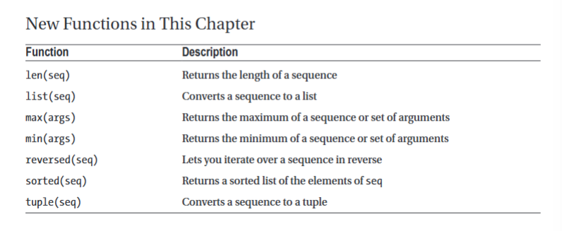